# TZ Gaming: Optimal Targeting of Mobile Ads

- Name:Qiuyi LU
- GitLab id: “rsm-q2lu”

## Setup

Please complete this Rmarkdown document by answering the questions in `tz-gaming.pdf` on Canvas (week5/). Create a Notebook/HTML file with all your results and comments and push both the Rmarkdown and HTML file to GitLab when you are done. All results MUST be reproducible (i.e., the TA and I must be able to recreate the HTML from the Rmarkdown file without changes or errors).

> Note: If you use Rstudio’s git tab to push your submission to GitLab you may see warnings or messages when pushing the HTML file because of its size. To avoid these messages you can also push your files to GitLab by using GitGadget’s “Sync” tab (i.e., Commit your changes and then Push).

```r
## loading the data - this dataset must NOT be changed
tz_gaming <- readr::read_rds("data/tz_gaming.rds")
radiant.data::describe(tz_gaming)
```

[output not shown]

## Question answers

```r
tz_gaming=tz_gaming %>% mutate(label=ifelse(click == 'no',0,1))

traindata=tz_gaming[tz_gaming$training=='train',]
testdata=tz_gaming[tz_gaming$training=='test',]
```

### Part I: Logistic Regression (10 points)

#### a.predict the probability of click == “yes” on total data

```r
f1 = label ~ impup+ clup+ ctrup+ impua+ clua+ ctrua+ imput+ clut+ ctrut+ imppat+ clpat+ctrpat


glm.fits=glm(formula=f1,data=traindata,family=binomial)
summary(glm.fits)
```

```
Call:
glm(formula = f1, family = binomial, data = traindata)

Deviance Residuals:
    Min       1Q   Median       3Q      Max
-3.4559  -0.1400  -0.1082  -0.0735   4.4716

Coefficients:
               Estimate  Std. Error z value             Pr(>|z|)
(Intercept) -4.96329480  0.08731593 -56.843 < 0.0000000000000002 ***
impup        0.00003082  0.00009500   0.324             0.745655
clup         0.00976789  0.00356159   2.743             0.006096 **
ctrup        0.02982061  0.00431262   6.915  0.00000000000468772 ***
impua       -0.01378618  0.00232876  -5.920  0.00000000321988338 ***
clua         0.04453776  0.07013130   0.635             0.525388
ctrua        0.00774882  0.00281371   2.754             0.005888 **
imput       -0.00475964  0.00113804  -4.182  0.00002885487106449 ***
clut         0.22642126  0.02139766  10.582 < 0.0000000000000002 ***
ctrut        0.03039132  0.00329176   9.233 < 0.0000000000000002 ***
imppat      -0.00001670  0.00000466  -3.583             0.000339 ***
clpat        0.00147865  0.00034143   4.331  0.00001486347550020 ***
ctrpat       0.30708933  0.03926822   7.820  0.00000000000000527 ***
---
Signif. codes:  0 '***' 0.001 '**' 0.01 '*' 0.05 '.' 0.1 ' ' 1

(Dispersion parameter for binomial family taken to be 1)

    Null deviance: 8860.4  on 87534  degrees of freedom
Residual deviance: 7560.1  on 87522  degrees of freedom
AIC: 7586.1

Number of Fisher Scoring iterations: 9
```

```r
click_logit=predict(glm.fits, newdata = tz_gaming, type = "response")


OR=exp(coef(glm.fits))
cbind(OR,coefficient=coef(glm.fits))
```

```
                    OR    coefficient
(Intercept) 0.00698986 -4.96329480296
impup       1.00003082  0.00003081459
clup        1.00981575  0.00976788563
ctrup       1.03026970  0.02982061443
impua       0.98630841 -0.01378618414
clua        1.04554446  0.04453776294
ctrua       1.00777892  0.00774881704
imput       0.99525167 -0.00475964206
clut        1.25410386  0.22642126329
ctrut       1.03085785  0.03039132049
imppat      0.99998330 -0.00001669832
clpat       1.00147974  0.00147864968
ctrpat      1.35946240  0.30708932791
```

##### The regression output shows that these variables: clup, ctrup, ctrua, imput, clut, ctrut, imppat, clpat, ctrpat are statistically significant predictor of customer purchase. Only 2 variables impup and clua are not significant.

##### ctrpat seems to be the most “important” becasue its absolute value of coefficient is larger than others.

##### For example, the coefficient of clup from the logistic regression is 0.00976 and the odds ratio is equal to 1.009808 (i.e., e^ 0.00976). Because the odds ratio is larger than 1, a higher number of past impressions the user has clicked on in the app is associated with higher odds of click. If the odds ratio is smaller than 1, then a higher number of the variable(such as impua,imput , imppat) is associated with a lower odds of click.

##### Also, because these p.value for the coefficient is smaller than 0.05, we conclude that (1) the coefficients are statistically significantly different from 0 and (2) the odds ratios are statistically significantly different from 1. An odds ratio of 1 is equivalent to a coefficient estimate of 0 in a linear regression and implies that the explanatory (or predictor) variable has no effect on the response variable. The estimated odds ratio of 1.009808 suggests that the odds of click increase by 0.98% for each clup increase.

### Part II: Decile Analysis of Logistic Regression Results (10 points)

#### a. Assign each impression to a decile based on the predicted probability of click through. Create a new variable dec_logit that captures this information. Note: The first decile should have the highest average click-through rate. If not, make sure to “reverse” the decile numbers (i.e., 10 becomes 1, 9 becomes 2, etc.). Please use the xtile function to create the deciles.

```r
testdata$pred_pro=predict(glm.fits, newdata = testdata, type = "response")
testdata = testdata%>% mutate(dec_logit=xtile(pred_pro,10,rev=TRUE))
```

#### b. Create a bar chart of click-through rates per decile (i.e., use dec_logit as the x-variable and click == “yes” as the y-variable). Note that the “click through rate” is not the same as the “predicted probability of click.” The click through rate captures the proportion of impressions in a given group (e.g., in a decile) that actually resulted in a click.

```r
visualize(testdata,
        xvar = "dec_logit",
  yvar = "click",
  type = "bar",
  labs = list(
    y = "Proportion of click = 'yes'",
    x = "dec of probability of click"
  ),
  custom = FALSE
)
```

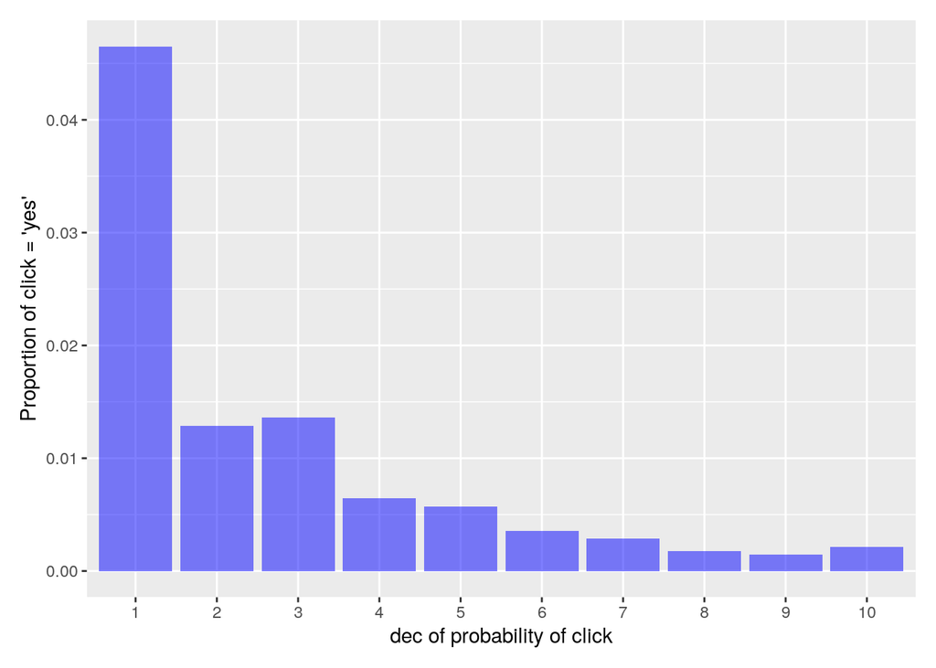

#### c. Report the number of impressions, the number of clicks, and the click-through rate for the TZ ad per decile and save this information to a dataframe. Use the name dec_df_logit for the new data frame

```r
dec_df_logit= testdata %>% group_by(dec_logit) %>% summarize(number_impression=n(),number_click=sum(label),click_through_rate=number_click/number_impression)
```

#### d. Estimate a logistic regression model with click as the response variable and imppat, clpat, and ctrpat as the only explanatory variable. Make sure to “standardize” the explanatory variables before estimation. What is the interpretation of the standardized odds-ratios for the explanatory variables?

```r
traindata_std=traindata %>% mutate(std_imppat=standardize(imppat), std_clpat=standardize(clpat),std_ctrpat=standardize(ctrpat))

result2= radiant.model::logistic(traindata_std,rvar='click',evar=c('std_imppat','std_clpat','std_ctrpat'),lev='yes')
summary(result2)
```

```
Logistic regression (GLM)
Data                 : traindata_std
Response variable    : click
Level                : yes in click
Explanatory variables: std_imppat, std_clpat, std_ctrpat
Null hyp.: there is no effect of x on click
Alt. hyp.: there is an effect of x on click

                OR coefficient std.error  z.value p.value
 (Intercept)            -4.915     0.043 -114.229  < .001 ***
 std_imppat  0.366      -1.005     0.209   -4.802  < .001 ***
 std_clpat   3.419       1.229     0.215    5.713  < .001 ***
 std_ctrpat  1.423       0.353     0.025   13.933  < .001 ***

Signif. codes:  0 '***' 0.001 '**' 0.01 '*' 0.05 '.' 0.1 ' ' 1

Pseudo R-squared: 0.035
Log-likelihood: -4273.088, AIC: 8554.176, BIC: 8591.695
Chi-squared: 314.248 df(3), p.value < .001
Nr obs: 87,535
```

##### It means if a variable is further from its mean value, the odds of clicking the ad will increase or decrease. For example, the odds ratio of standardized imppat is equal to 0.366. Because the odds ratio is smaller than 1, the further imppat(Number of past impressions that showed the TZ ad in the app in the hour) leave from its mean, the lower odds of click. The estimated odds ratio of 0.366 suggests that the odds of click decrease by about 64% for each standard deviation of imppat increase.

#### e. Q: Some of the variables in the dataset are highly correlated with each other. In particular, imppat and clpat have a positive correlation of 0.97. Discuss the implications of this (very) high level of collinearity and also different approaches to deal with it.

##### The collinearity will decrease the effectivess of the model. The ways to solve it are (1) to drop some variable and see if the result of the model is improved. (2) use PCA or other feature engineering methods to reduce the dimension of features such as create a new feature of ratio to represent two original features.

#### Q: What are the implications for the model and the interpretation of the estimated (standardized) coefficients?

##### By standardizing the explanatory variables before estimation we can see which variables move-the-needle most. For example, the coefficient of std_imppat from the logistic regression is -1.00496 and the odds ratio is equal to 0.3660593 (i.e., e^-1.00496). Because the odds ratio is smaller than 1, the further imppat(Number of past impressions that showed the TZ ad in the app in the hour) leave from its mean, the lower odds of click. The estimated odds ratio of 0.3660593 suggests that the odds of click decrease by about 64% for each standard deviation of imppat increase.

#### Q: As part of your answer, discuss the change in the estimated (standardized) odd-ratio for imppat when you remove clpat from the model.

```r
#remove clpat from the model.

result3= radiant.model::logistic(traindata_std,rvar='click',evar=c('std_imppat','std_ctrpat'),lev='yes')
summary(result3)
```

```
Logistic regression (GLM)
Data                 : traindata_std
Response variable    : click
Level                : yes in click
Explanatory variables: std_imppat, std_ctrpat
Null hyp.: there is no effect of x on click
Alt. hyp.: there is an effect of x on click

                OR coefficient std.error  z.value p.value
 (Intercept)            -4.859     0.040 -121.262  < .001 ***
 std_imppat  1.188       0.173     0.032    5.460  < .001 ***
 std_ctrpat  1.499       0.404     0.022   18.422  < .001 ***

Signif. codes:  0 '***' 0.001 '**' 0.01 '*' 0.05 '.' 0.1 ' ' 1

Pseudo R-squared: 0.031
Log-likelihood: -4290.903, AIC: 8587.805, BIC: 8615.945
Chi-squared: 278.619 df(2), p.value < .001
Nr obs: 87,535
```

#### f. Estimate another logistic regression model with click as the response variable and time_fct, app, imppat, clpat, and ctrpat as the explanatory variable.

```r
result4= radiant.model::logistic(traindata,rvar='click',evar=c('imppat','ctrpat','clpat','time_fct','app'),lev='yes')
summary(result4)
```

```
Logistic regression (GLM)
Data                 : traindata
Response variable    : click
Level                : yes in click
Explanatory variables: imppat, ctrpat, clpat, time_fct, app
Null hyp.: there is no effect of x on click
Alt. hyp.: there is an effect of x on click

                OR coefficient std.error z.value p.value
 (Intercept)            -4.424     0.284 -15.575  < .001 ***
 imppat      1.000      -0.000     0.000  -1.131   0.258
 ctrpat      1.077       0.075     0.117   0.637   0.524
 clpat       1.001       0.001     0.001   1.135   0.256
 time_fct|2  0.588      -0.532     0.323  -1.644   0.100
 time_fct|3  0.693      -0.367     0.461  -0.795   0.426
 time_fct|4  0.000     -14.834   487.743  -0.030   0.976
 time_fct|5  0.000     -14.860   635.984  -0.023   0.981
 time_fct|6  0.359      -1.025     1.027  -0.999   0.318
 time_fct|7  1.220       0.199     0.438   0.453   0.650
 time_fct|8  1.135       0.127     0.309   0.411   0.681
 time_fct|9  1.063       0.061     0.299   0.203   0.839
 time_fct|10 0.843      -0.170     0.303  -0.561   0.575
 time_fct|11 0.637      -0.451     0.288  -1.565   0.118
 time_fct|12 0.834      -0.181     0.292  -0.620   0.535
 time_fct|13 0.535      -0.626     0.306  -2.047   0.041 *
 time_fct|14 0.982      -0.018     0.257  -0.069   0.945
 time_fct|15 0.840      -0.174     0.272  -0.639   0.523
 time_fct|16 0.874      -0.135     0.279  -0.483   0.629
 time_fct|17 0.864      -0.146     0.296  -0.493   0.622
 time_fct|18 0.942      -0.060     0.286  -0.208   0.835
 time_fct|19 1.178       0.164     0.251   0.651   0.515
 time_fct|20 1.188       0.172     0.247   0.698   0.485
 time_fct|21 0.782      -0.245     0.261  -0.942   0.346
 time_fct|22 0.933      -0.069     0.259  -0.267   0.789
 time_fct|23 0.993      -0.007     0.268  -0.025   0.980
 time_fct|24 1.134       0.125     0.258   0.486   0.627
 app|app2    0.136      -1.997     0.351  -5.681  < .001 ***
 app|app3    0.187      -1.675     1.016  -1.649   0.099 .
 app|app4    0.487      -0.719     0.359  -2.004   0.045 *
 app|app5    0.413      -0.883     1.011  -0.874   0.382
```

[output cut: 36 more lines]

```
 app|app42   2.909       1.068     0.452   2.363   0.018 *
 app|app43   0.000     -15.109   843.185  -0.018   0.986
 app|app44   0.000     -15.047   517.344  -0.029   0.977
 app|app45   1.920       0.652     0.604   1.079   0.281
 app|app46   0.466      -0.763     1.020  -0.748   0.455
 app|app47   0.406      -0.902     1.012  -0.891   0.373
 app|app48   0.000     -15.045  1178.615  -0.013   0.990
 app|app49   0.259      -1.349     1.019  -1.324   0.185

Signif. codes:  0 '***' 0.001 '**' 0.01 '*' 0.05 '.' 0.1 ' ' 1

Pseudo R-squared: 0.056
Log-likelihood: -4180.646, AIC: 8511.292, BIC: 9214.776
Chi-squared: 499.132 df(74), p.value < .001
Nr obs: 87,535
```

#### Part III: Lift and Gains (5 points)

##### a. Use the data frame you created in II.c above to generate a table with lift and cumulative lift numbers for each decile.

```r
dec_df_logit_lift= dec_df_logit %>% mutate(cum_number_impression=cumsum(number_impression),
                                      cum_number_click=cumsum(number_click),
                                      ave_click_through_rate=sum(number_click)/sum(number_impression),
                                      lift=click_through_rate/ave_click_through_rate,
                                      cum_click_through_rate=cum_number_click/cum_number_impression,
                                      cum_lift=cum_click_through_rate/ave_click_through_rate,

                                      )

dec_df_logit_lift
```

```
# A tibble: 10 x 10
   dec_logit number_impression number_click click_through_rate cum_number_impression cum_number_click ave_click_through_rate  lift cum_click_through_rate cum_lift
       <int>             <int>        <dbl>              <dbl>                 <int>            <dbl>                  <dbl> <dbl>                  <dbl>    <dbl>
 1         1              2796          130            0.0465                   2796              130                0.00969 4.80                 0.0465      4.80
 2         2              2795           36            0.0129                   5591              166                0.00969 1.33                 0.0297      3.06
 3         3              2795           38            0.0136                   8386              204                0.00969 1.40                 0.0243      2.51
 4         4              2795           18            0.00644                 11181              222                0.00969 0.664                0.0199      2.05
 5         5              2795           16            0.00572                 13976              238                0.00969 0.590                0.0170      1.76
 6         6              2796           10            0.00358                 16772              248                0.00969 0.369                0.0148      1.53
 7         7              2795            8            0.00286                 19567              256                0.00969 0.295                0.0131      1.35
 8         8              2795            5            0.00179                 22362              261                0.00969 0.185                0.0117      1.20
 9         9              2795            4            0.00143                 25157              265                0.00969 0.148                0.0105      1.09
10        10              2796            6            0.00215                 27953              271                0.00969 0.221                0.00969     1
```

#### b. Create a ggplot (or matplotlib or altair) chart showing the cumulative lift per decile

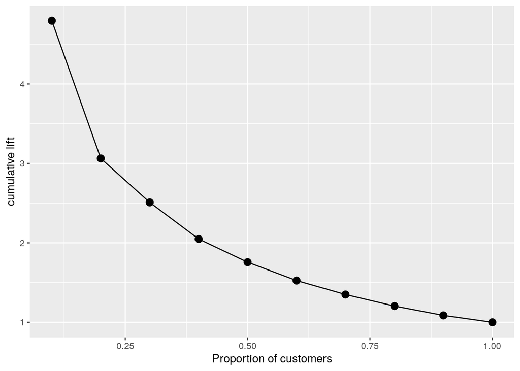

```r
dec_df_logit_lift%>%ggplot(aes(x=dec_logit/10,y=cum_lift,group=1))+geom_line()+geom_point(size=3)+labs(x='Proportion of customers',y='cumulative lift')
```

#### c. Use the data frame you created in II.c above to generate a table with gains and cumulative gains numbers for each decile.

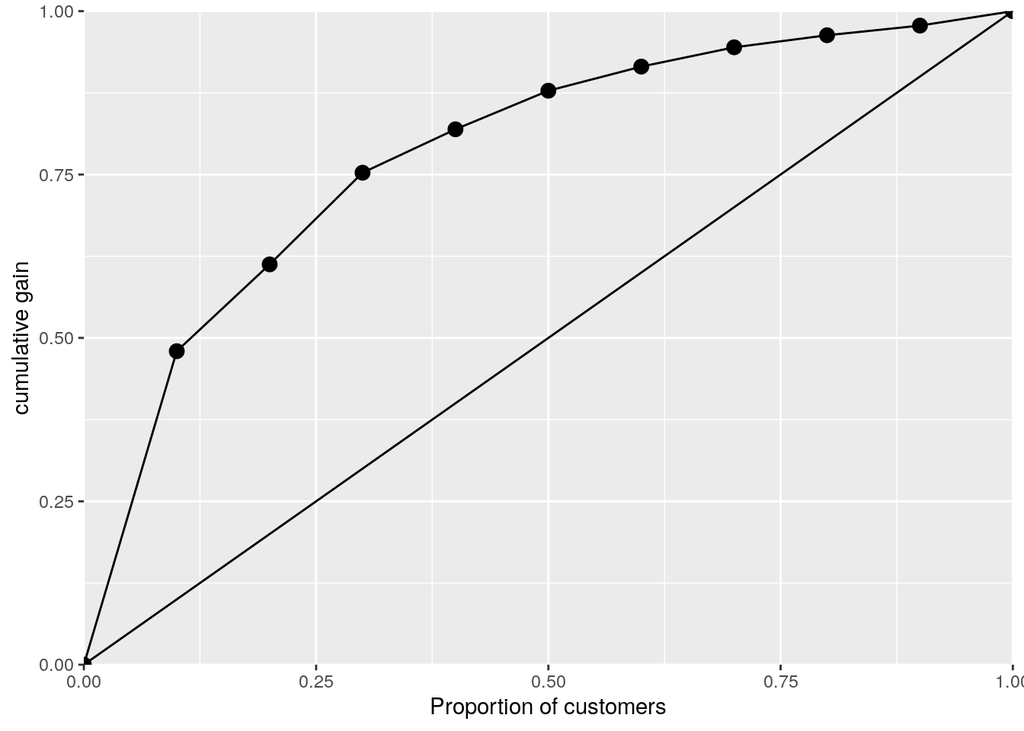

```r
dec_df_logit_gain= dec_df_logit %>% mutate(cum_number_impression=cumsum(number_impression),
                                      cum_number_click=cumsum(number_click),
                                      gains=number_click/sum(number_click),
                                      cum_gains=cum_number_click/sum(number_click)
                                      )

dec_df_logit_gain2=dec_df_logit_gain%>% rbind(rep(0,8))

dec_df_logit_gain2%>%ggplot(aes(x=dec_logit/10,y=cum_gains,group=1))+geom_line()+geom_point(size=3)+labs(x='Proportion of customers',y='cumulative gain')+scale_y_continuous(breaks=seq(0,1,0.25),expand = c(0, 0),limits = c(0,1)) +scale_x_continuous(breaks=seq(0,1,0.25),expand = c(0, 0),limits = c(0,1)) + geom_abline(intercept=0,slope=1)
```

#### Part IV: Confusion matrix (5 points)

1. Create a “confusion matrix” based on the predictions from the logistic regression model you estimatedabove for I.a. Again, use onlydata from the test set here (i.e., “training == ‘test’”). Use the financial assumptions mentioned above, and repeated in section V below, to determine an appropriate cut-off. Calculate “accuracy” based on the confusion matrix you created (see http://lab.rady.ucsd.edu/sawtooth/RBusinessAnalytics/logit_models.html for an example using R).

```r
#Use the financial assumptions mentioned above, and repeated in section V below, to determine an appropriate cut-off.
#tz_gaming_user= tz_gaming %>% count(id)
cost_per_user=10/1000
margin=25
conversion=0.05
cut_off=cost_per_user/margin/conversion


## confusion matrix for f1
test_data=testdata%>%
  mutate(pred_click=ifelse(pred_pro > cut_off,'Pred.Click','Pred.Notclick'))

conf.mat <- table(test_data$click,test_data$pred_click)

accuracy=as.numeric(conf.mat[1,1]+conf.mat[2,2])/sum(conf.mat)
accuracy
```

```
[1] 0.6509856
```

##### b. Calculate a confusion matrix based on predictions from a logistic regression with click as the response variable andrndas the onlyexplanatory variable. As before, the model should be estimated ontraining sample (i.e., “training == ‘train’”). Generate predictions for all rows in the data and createthe confusion matrix based only on the test set (i.e., “training == ‘train’”). Calculate “accuracy”based on the confusion matrix you created.

```r
f5 = label ~ rnd

glm.fits5=glm(formula=f5,data=traindata,family=binomial)

tz_gaming$click_rnd=predict(glm.fits5, newdata = tz_gaming, type = "response")
tz_gaming=tz_gaming %>% mutate(target_rnd=ifelse(click_rnd>cut_off,TRUE,FALSE))


test_data5=testdata
test_data5$pred_pro=predict(glm.fits5, newdata = testdata, type = "response")

test_data5=test_data5%>%
  mutate(pred_click=ifelse(pred_pro > cut_off,'Pred.Click','Pred.Notclick'))

conf.mat2 <- table(test_data5$click,test_data5$pred_click)

accuracy2=as.numeric(conf.mat2[1,1]+conf.mat2[2,2])/sum(conf.mat2)
accuracy2
```

```
[1] 0.01241369
```

##### c. Discuss the similarities and differences between the two confusion matrices. Which model is best basedon the confusion matrix? Provide support for your conclusions.

```r
conf.mat
```

```
      Pred.Click Pred.Notclick
  yes        213            58
  no        9698         17984
```

```r
conf.mat2
```

```
      Pred.Click Pred.Notclick
  yes        271             0
  no       27606            76
```

##### Model 1 is better than Model2 because, first, the most important factor is true positive. The difference of the two model is not large. One is 271 and one is 213. Then looking at the true negative, model two has 76 but model one has 17984. This means model one could help the company to save money to not target the people who won’t click. And the overall accuracy of model one is 65% while model two is only 1.2%.So model one is better.

##### d. Recalculate the confusion matrices from IV.a and IV.b using 0.5 as the cutoff. Based on these newmatrices, discuss again the similarities and differences. Which model is best based on the confusionmatrix? Provide support for your conclusions.

```r
## confusion matrix for IV.a
newcutoff=0.5
test_data_newcutoff=testdata%>%
  mutate(pred_click=ifelse(pred_pro > newcutoff,'Pred.Click','Pred.Notclick'))

conf.matNew <- table(test_data_newcutoff$click,test_data_newcutoff$pred_click)

accuracyNew=as.numeric(conf.matNew[1,1]+conf.matNew[2,2])/sum(conf.matNew)
accuracyNew
```

```
[1] 0.9898759
```

```r
test_data5_newcutoff=test_data5%>%
  mutate(pred_click=ifelse(pred_pro > newcutoff,'Pred.Click','Pred.Notclick'))

conf.mat2New <- table(test_data5_newcutoff$click,test_data5_newcutoff$pred_click)

accuracy2New=as.numeric(conf.mat2New[2,1])/sum(conf.mat2New)
accuracy2New
```

```
[1] 0.9903052
```

```r
conf.matNew
```

```
      Pred.Click Pred.Notclick
  yes          9           262
  no          21         27661
```

```r
conf.mat2New
```

```
      Pred.Notclick
  yes           271
  no          27682
```

##### similarities : Most of the data are predicted not click by both of the models.

##### differences : Model two is more conservative. It is more likely to predict not click than model1. As a result, model 2’s TN and accuracy are higher because in the data, most people didn’t click. But model 2’s FN is also higher. Model 1’s TP is higher,which is good but FP is also higher.

##### Model 1 is better than Model2 because model two is a naive predictive model. It predict all not click. If we use the model, we won’t send any ads to customers and how could we earn money? In terms of the matrics. First, the most important factor is true positive. Model two is zero and model one is 9. Then looking at the true negative, model two has 27682 but model one has 27661. The difference is only 21. It won’t waste too much money for the company. In all, model one will help the company earn more money.

#### Part V: Profitability Analysis (5 points)

##### a. What is the break-even response rate?

```r
cut_off
```

```
[1] 0.008
```

##### b. Create a new variable target_logit that is TRUE if the predicted click-through probability is greaterthan the break-even response rate and FALSE otherwise

```r
tz_gaming$click_logit=click_logit
tz_gaming=tz_gaming%>% mutate(target_logit=ifelse(click_logit > cut_off,TRUE,FALSE))
target_logit=tz_gaming$target_logit

tz_gaming_test=tz_gaming%>% filter(training=='test')
```

##### c. For the test set (i.e, “training == ‘test’”), what is the expected profit (in dollars) and the expected return on marketing expenditures (ROME) if TZ used (1) no targeting, (2) purchased the data fromVneta and used the logistic regression from I.a for targeting, or (3) used Vneta’s data science consultingservices? You can use theclick_vnetavariable to create atarget_vnetavariable and calculate theexpected profit and the expected return on marketing expenditures

##### no targeting:

```r
click_rnd=ifelse(test_data5$pred_click=='Pred.Click',TRUE,FALSE)

conf.mat2
```

```
      Pred.Click Pred.Notclick
  yes        271             0
  no       27606            76
```

```r
cpm=10/1000
revenue=conf.mat2[1,1]*margin*conversion
cost=sum(click_rnd)*cpm
exp_profit=revenue-cost
print(paste0("The expected profit (in dollars) of no targeting is ",exp_profit))
```

```
[1] "The expected profit (in dollars) of no targeting is 59.98"
```

```r
exp_ROME=exp_profit/cost
print(paste0("The expected ROME  of no targeting is ",round(exp_ROME,2)))
```

```
[1] "The expected ROME  of no targeting is 0.22"
```

##### purchased the data from Vneta and used the logistic regression from I.a for targeting:

```r
revenue=conf.mat[1,1]*margin*conversion

cost= sum(tz_gaming_test$target_logit)*cpm
exp_profit=revenue-cost
print(paste0("The expected profit (in dollars) of targeting on our own is ",exp_profit))
```

```
[1] "The expected profit (in dollars) of targeting on our own is 167.14"
```

```r
exp_ROME=exp_profit/cost
print(paste0("The expected ROME of targeting on our own is ",round(exp_ROME,2)))
```

```
[1] "The expected ROME of targeting on our own is 1.69"
```

##### used Vneta’s data science consulting services? You can use the click_vneta variable to create a target_vneta variable and calculate the expected profit and the expected return on marketing expenditures

```r
tz_gaming_test=tz_gaming_test %>% mutate(target_vneta=ifelse(click_vneta>cut_off,TRUE,FALSE))
TP=tz_gaming_test %>% filter(target_vneta==TRUE,label==1)

revenue=nrow(TP)*margin*conversion

cost= sum(tz_gaming_test$target_vneta)*cpm
exp_profit=revenue-cost
print(paste0("The expected profit (in dollars) of buying DS service is ",exp_profit))
```

```
[1] "The expected profit (in dollars) of buying DS service is 151.29"
```

```r
exp_ROME=exp_profit/cost
print(paste0("The expected ROME of targeting buying DS service is ",round(exp_ROME,2)))
```

```
[1] "The expected ROME of targeting buying DS service is 3.11"
```

##### d. Predict the profit and ROME implications for each of the 3 options if TZ purchases 20-million impression for the upcoming ad campaign? Use the results from (c) above to project the performance implications.

##### Here, I made the following assumptions about the 20M data: (1) assume the 20M data has the same overall click through rate as the current tz_game data(average_click_throughrate) without targeting (2)assume the true positive rate(TPR) and the rate of predicted true(pred_true_rate) of our model are the same as we calculated in the test data.

```r
DS_cost=150000
purchase_cost=50000
total=20000000


#option1 no targeting:

TP=conf.mat2[1,1]
pred_true=sum(click_rnd)
pred_true_rate=TP/pred_true
revenue=pred_true_rate*total*margin*conversion

cost= total*cpm
other_cost=0
exp_profit=revenue-cost-other_cost
print(paste0("The expected profit (in dollars) of no targeting is ",exp_profit))
```

```
[1] "The expected profit (in dollars) of no targeting is 43031.8900886035"
```

```r
exp_ROME=exp_profit/(cost+other_cost)
print(paste0("The expected ROME of targeting no targeting is ",round(exp_ROME,2)))
```

```
[1] "The expected ROME of targeting no targeting is 0.22"
```

```r
#purchased the data from Vneta and used the logistic regression from I.a for targeting:
TP=conf.mat[1,1]
pred_true=sum(tz_gaming_test$target_logit)
pred_true_rate=TP/pred_true
revenue=pred_true_rate*total*margin*conversion

other_cost=purchase_cost
exp_profit=revenue-cost-other_cost
print(paste0("The expected profit (in dollars) of targeting on our own is ",exp_profit))
```

```
[1] "The expected profit (in dollars) of targeting on our own is 287281.808092019"
```

```r
exp_ROME=exp_profit/(cost+other_cost)
print(paste0("The expected ROME of targeting on our own is ",round(exp_ROME,2)))
```

```
[1] "The expected ROME of targeting on our own is 1.15"
```

```r
#use ds

TP=tz_gaming_test %>% filter(target_vneta==TRUE,label==1)
TP=nrow(TP)

pred_true=sum(tz_gaming_test$target_vneta)
pred_true_rate=TP/pred_true
revenue=pred_true_rate*total*margin*conversion


other_cost=DS_cost
exp_profit=revenue-cost-other_cost
print(paste0("The expected profit (in dollars) of buying DS service is ",exp_profit))
```

```
[1] "The expected profit (in dollars) of buying DS service is 471186.614658181"
```

```r
exp_ROME=exp_profit/(cost+other_cost)
print(paste0("The expected ROME of targeting buying DS service is ",round(exp_ROME,2)))
```

```
[1] "The expected ROME of targeting buying DS service is 1.35"
```

#### Part VI: Model comparison (10 points)

##### Calculate the confidence interval for the predictions from the logistic regression model in 1.a. Now redo the calculations from V.b through V.d, adjusting for these errors. How do the results change?

```r
result_conf= radiant.model::logistic(traindata,rvar='click',evar=c('impup', 'clup', 'ctrup', 'impua','clua', 'ctrua','imput', 'clut', 'ctrut', 'imppat', 'clpat','ctrpat'),lev='yes')

conf_logit=predict(result_conf, pred_data = tz_gaming, conf_lev = 0.9, se = TRUE)

tz_gaming=tz_gaming%>% mutate(click_logit_lb=conf_logit$`5%`,click_logit_ub=conf_logit$`95%`)
```

##### Redo b:Create a new variable target_logit that is TRUE if the predicted click-through probability is greater than the break-even response rate and FALSE otherwise

```r
tz_gaming=tz_gaming%>%
  mutate(target_logit_lb=ifelse(click_logit_lb > cut_off,TRUE,FALSE))
target_logit_lb=tz_gaming$target_logit_lb

tz_gaming_test_conf=tz_gaming%>% filter(training=='test')
```

##### redo c. For the test set (i.e, “training == ‘test’”), what is the expected profit (in dollars) and the expected return on marketing expenditures (ROME) if TZ used (1) no targeting, (2) purchased the data from Vneta and used the logistic regression from I.a for targeting, or (3) used Vneta’s data science consulting services? You can use the click_vneta variable to create a target_vneta variable and calculate the expected profit and the expected return on marketing expenditures

```r
##### purchased the data from Vneta and used the logistic regression from I.a for targeting:

conf.mat.conf <- table(tz_gaming_test_conf$click,tz_gaming_test_conf$target_logit_lb)
revenue=conf.mat.conf[1,2]*margin*conversion
cost= sum(tz_gaming_test_conf$target_logit_lb)*cpm
exp_profit=revenue-cost
print(paste0("The expected profit (in dollars) of targeting on our own with lower bound is ",exp_profit))
```

```
[1] "The expected profit (in dollars) of targeting on our own with lower bound is 166.4"
```

```r
exp_ROME=exp_profit/cost
print(paste0("The expected ROME of targeting on our own with lower bound is ",round(exp_ROME,2)))
```

```
[1] "The expected ROME of targeting on our own with lower bound is 2.02"
```

##### d. Predict the profit and ROME implications for each of the 3 options if TZ purchases 20-million impression for the upcoming ad campaign? Use the results from (c) above to project the performance implications.

```r
#purchased the data from Vneta and used the logistic regression from I.a for targeting:
TP=conf.mat.conf[1,2]
pred_true=sum(tz_gaming_test_conf$target_logit_lb)
pred_true_rate=TP/pred_true
revenue=pred_true_rate*total*margin*conversion
cost= total*cpm

other_cost=purchase_cost
exp_profit=revenue-cost-other_cost
print(paste0("The expected profit (in dollars) of targeting on our own with lower bound is ",exp_profit))
```

```
[1] "The expected profit (in dollars) of targeting on our own with lower bound is 354128.718882817"
```

```r
exp_ROME=exp_profit/(cost+other_cost)
print(paste0("The expected ROME of targeting on our own with lower bound is ",round(exp_ROME,2)))
```

```
[1] "The expected ROME of targeting on our own with lower bound is 1.42"
```

##### The test profit using logit_lb is slightly lower than not using the lower bound but logit_lb yields a higher expected profit in 20m impressions and ROME in both test and 20m impressions.

##### b. The calculations in V.b through V.d above are based on a model that did not include all available variables. Not all variables may be relevant however. To at least give each variable available in the dataset a change of being included in the model, estimate a (“backward”) stepwise logistic regression model, starting with the following variables:

##### time_fct, app, impup, clup, ctrup, impua, clua, ctrua, imput, clut, ctrut, imppat, clpat Create a variable (click_logit_stepwise_pre) with predicted click-through probabilities from this model. Also create a variable (target_logit_stepwise) that is TRUE if the predicted click-through probability is greater than the break-even response rate and FALSE otherwise.

```r
stepwise <- logistic(
  traindata,
  rvar = "click",
  evar = c(
    "time_fct","app","impup", "clup", "ctrup","impua", "clua", "ctrua", "imput", "clut", "ctrut", "imppat", "clpat","ctrpat"
  ),
  lev = "yes",
  check = "stepwise-backward"
)
```

```
Start:  AIC=7590.17
click ~ time_fct + app + impup + clup + ctrup + impua + clua +
    ctrua + imput + clut + ctrut + imppat + clpat + ctrpat

           Df Deviance    AIC
- time_fct 23   7459.0 7581.0
- app      48   7515.2 7587.2
- impup     1   7422.2 7588.2
- clua      1   7422.2 7588.2
- clpat     1   7422.7 7588.7
- imppat    1   7422.8 7588.8
- ctrpat    1   7422.9 7588.9
<none>          7422.2 7590.2
- clup      1   7425.8 7591.8
- ctrua     1   7428.6 7594.6
- imput     1   7439.7 7605.7
- impua     1   7460.5 7626.5
- ctrup     1   7469.6 7635.6
- ctrut     1   7485.9 7651.9
- clut      1   7530.5 7696.5

Step:  AIC=7580.96
click ~ app + impup + clup + ctrup + impua + clua + ctrua + imput +
    clut + ctrut + imppat + clpat + ctrpat

         Df Deviance    AIC
- impup   1   7459.0 7579.0
- clua    1   7459.0 7579.0
- imppat  1   7459.6 7579.6
- clpat   1   7460.0 7580.0
- ctrpat  1   7460.3 7580.3
<none>        7459.0 7581.0
- clup    1   7462.5 7582.5
- app    48   7560.1 7586.1
- ctrua   1   7466.3 7586.3
- imput   1   7475.8 7595.8
- impua   1   7498.5 7618.5
- ctrup   1   7504.4 7624.4
- ctrut   1   7522.7 7642.7
- clut    1   7567.0 7687.0
```

[output cut: 55 more lines]

```
Step:  AIC=7575.21
click ~ app + clup + ctrup + impua + ctrua + imput + clut + ctrut +
    ctrpat

         Df Deviance    AIC
<none>        7461.2 7575.2
- ctrpat  1   7464.0 7576.0
- clup    1   7465.7 7577.7
- ctrua   1   7471.2 7583.2
- imput   1   7488.4 7600.4
- ctrup   1   7506.6 7618.6
- app    48   7601.4 7619.4
- impua   1   7514.6 7626.6
- ctrut   1   7524.9 7636.9
- clut    1   7576.5 7688.5
```

```r
click_logit_stepwise <- predict(stepwise, pred_data = tz_gaming)
click_logit_step_pre=click_logit_stepwise$pred

tz_gaming=tz_gaming %>% mutate(target_logit_stepwise=ifelse(click_logit_step_pre>cut_off,TRUE,FALSE),target_vneta=ifelse(click_vneta>cut_off,TRUE,FALSE))
```

#### c. You have now estimated 4 different models and also have the predictions from Vneta. Compare the performance of implications for all 5 models based on profit calculations as in V.b through V.d and a gains chart. Discuss which of these 5 models you would recommend to put into production.

```r
# define a profit,ROME function
tz_gaming_test=tz_gaming %>% filter(training=='test')
calculate_prof_ROME=function(dataf,colname,coltext,other_cost){

TP=tz_gaming_test %>%filter (!! colname==TRUE,label==1)
revenue=nrow(TP)*margin*conversion
cost= sum(tz_gaming_test[[coltext]])*cpm
exp_profit=revenue-cost
exp_ROME=exp_profit/cost
testresult=data.frame(method=coltext,test_profit=exp_profit,test_ROME=round(exp_ROME,2))


pred_true=sum(tz_gaming_test[[coltext]])
pred_true_rate=nrow(TP)/pred_true
revenue=pred_true_rate*total*margin*conversion

cpm_cost=total*cpm
exp_profit=revenue-cpm_cost-other_cost
exp_ROME=exp_profit/(cpm_cost+other_cost)
realresult=data.frame(expected_profit=exp_profit,expected_ROME=round(exp_ROME,2))
tworesult=cbind(testresult,realresult)
return(tworesult)
}

logit_stepwise=calculate_prof_ROME(tz_gaming_test,quo(target_logit_stepwise),"target_logit_stepwise",purchase_cost)
logit_lb=calculate_prof_ROME(tz_gaming_test,quo(target_logit_lb),"target_logit_lb",purchase_cost)
logit_rnd=calculate_prof_ROME(tz_gaming_test,quo(target_rnd),"target_rnd",0)
logit_vneta=calculate_prof_ROME(tz_gaming_test,quo(target_vneta),"target_vneta",DS_cost)
logit=calculate_prof_ROME(tz_gaming_test,quo(target_logit),"target_logit",purchase_cost)

compare_profit_rome=rbind(logit_stepwise,logit_lb,logit_rnd,logit_vneta,logit) %>% arrange(desc(expected_profit))

compare_profit_rome
```

```
                 method test_profit test_ROME expected_profit expected_ROME
1          target_vneta      151.29      3.11       471186.61          1.35
2       target_logit_lb      166.40      2.02       354128.72          1.42
3          target_logit      167.14      1.69       287281.81          1.15
4 target_logit_stepwise      160.96      1.44       238613.95          0.95
5            target_rnd       59.98      0.22        43031.89          0.22
```

##### In terms of the total profit on 20m impressions, buying the service of Vneta will yield the highest profit.

##### In terms of the ROME on 20m impressions, using logistic regression adjusted with error will yield the highest return rate.

```r
#define a chart function
gain_chart=function(df,colname,colcontent){
df = df%>% mutate(dec_logit=xtile(!! colname,10,rev=TRUE))
dec_df_logit= df %>% group_by(dec_logit) %>% summarize(number_impression=n(),number_click=sum(label),click_through_rate=number_click/number_impression)
dec_df_logit_gain= dec_df_logit %>% mutate(cum_number_impression=cumsum(number_impression),
                                      cum_number_click=cumsum(number_click),
                                      gains=number_click/sum(number_click),
                                      cum_gains=cum_number_click/sum(number_click)
                                      )

dec_df_logit_gain2=dec_df_logit_gain%>% rbind(rep(0,8)) %>% select('dec_logit','cum_gains') %>% mutate(method=colcontent)

return(dec_df_logit_gain2)
}

table_click_logit_lb=gain_chart(tz_gaming_test,quo(click_logit_lb),"click_logit_lb")
table_click_logit=gain_chart(tz_gaming_test,quo(click_logit),"click_logit")

table_click_rnd=gain_chart(tz_gaming_test,quo(click_rnd),"click_rnd")

table_click_vneta=gain_chart(tz_gaming_test,quo(click_vneta),"click_vneta")

table_click_logit_step_pre=gain_chart(tz_gaming_test,quo(click_logit_step_pre),"click_logit_step_pre")

compare_gains=rbind(table_click_logit_lb,table_click_logit,table_click_logit_step_pre,table_click_rnd,table_click_vneta)
```

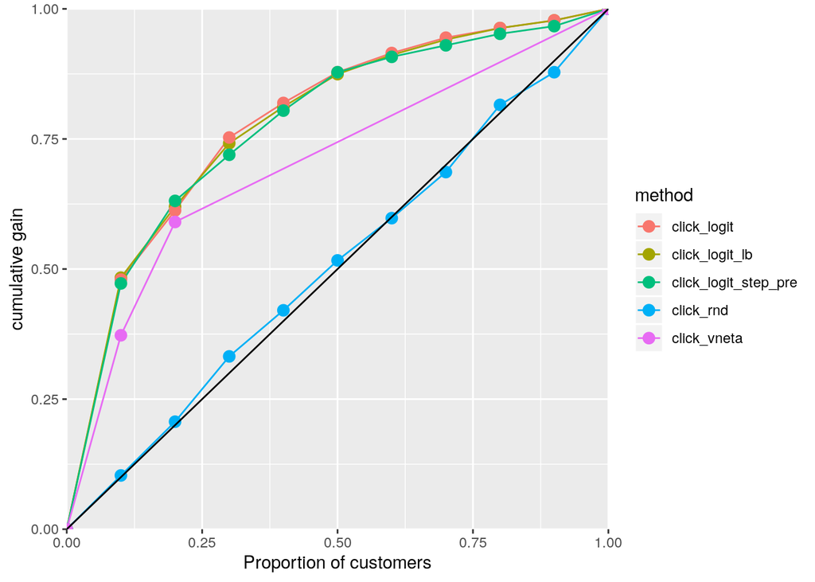

```r
plot=compare_gains%>%ggplot(aes(x=dec_logit/10,y=cum_gains,group=method,color=method))+geom_line()+geom_point(size=3)+labs(x='Proportion of customers',y='cumulative gain')+scale_y_continuous(breaks=seq(0,1,0.25),expand = c(0, 0),limits = c(0,1)) +scale_x_continuous(breaks=seq(0,1,0.25),expand = c(0, 0),limits = c(0,1)) + geom_abline(intercept=0,slope=1)

plot
```

##### As a result, I recommend using the Vneta as the first choice because it is expected to yield the hightest profit if they buy 20m impressions. But if they just buy a small amount of the impressions, they should consider logit lowerbound. The shreshold could be further calculated.